# Northern Three Spatial Analyses (eReefs Stars Method Presentation)

Author

Adam Shand

Published

October 27, 2023

**R Version**

For R session info at the time of rendering this script see Section 6.

**Note**

This is one part of several scripts exploring CSIRO ereefs data.

# 1 Introduction

This script provides detailed examples for producing eReefs outputs such as maps, graphs, and animation.

# 2 Script Set Up

This script requires multiple core spatial packages, all packages are loaded below.

```r
#load packages
library(stars)
library(ncmeta)
library(sf)
library(tidyverse)
library(ereefs)
library(here)
library(ggplot2)
#library(viridis)
#library(ggthemes)
library(tmap)
library(glue)
library(gganimate)
```

Then we also need to set up key variables for the script, as well as the output location.

```r
#set project crs
proj_crs <- params$project_crs

#create a file path to help with saving outputs
save_outputs <- here("outputs/n3_ereefs_s4_stars-method-presentation/")
save_data <- here("data/n3_ereefs_s4_stars-method-presentation/")

#bring the path to life
dir.create(save_outputs)
dir.create(save_data)

#write a note to the data folder
writeLines("No datasets are created from this script.", glue("{save_data}/note.txt"))

#turn off s2 geometry
sf_use_s2(FALSE)
```

# 3 Load Data

Now the script is set up we need to load in all of the required datasets. This will be broken into two segments:

- Spatial data specific to the N3 region - such as the region, basin, and sub basin boundaries.
- eReefs data

## 3.1 Spatial Data

Spatial data for the northern three regions should be readily available in the repo, the dataset is created by the n3_region-builder.qmd script in the repo that should be the first script run for new users. If the dataset is not available refer back to the README document in the GitHub repo. The other parts of spatial data here should go off without a hitch if the region-builder script has been run.

```r
#read in qld outlines data from the gisaimsr package, filter for land and islands, update crs
qld <- get(data("gbr_feat", package = "gisaimsr")) |> filter(FEAT_NAME %in% c("Mainland", "Island")) |>
  st_transform(proj_crs)

#read in the northern three spatial files and reduce down to only the components we need
n3_land_region <- st_read(here("data/n3_region-builder/n3_region.gpkg")) |> filter(environment != "Marine") |>
  group_by(sub_basin_or_sub_zone) |> summarise(geometry = st_union(geom)) |>
  ungroup() |> st_cast()

#get the boundary for the great barrier reef marine park
gbrmpa_bound <- get(data("gbr_bounds", package = "gisaimsr"))
```

## 3.2 eReefs Data

Now we can download several layers of eReefs data.

```r
#set bounding box, order is min lon, max lon, min lat, max lat
box_bounds <- c(145, 150, -22, -16)

#establish the initial file path using the ereefs package
#input_file <- substitute_filename("catalog")
input_file <- "https://dapds00.nci.org.au/thredds/dodsC/fx3/GBR1_H2p0_B3p2_Cfur_Dnrt.ncml"

#get all grids
grids <- get_ereefs_grids(input_file)

#get x and y specifically
x_grid <- grids[["x_grid"]]
y_grid <- grids[["y_grid"]]

#create an array of FALSE values the same dimensions as the x (and y) grids
outOfBox <- array(FALSE, dim = dim(x_grid))

#change array value to TRUE if the associated value in the x or y grid at the same position is outside our bounding box
if (!is.na(box_bounds[1])) {outOfBox <- apply(x_grid, 2, function(x) {(x < box_bounds[1] | is.na(x))})}
if (!is.na(box_bounds[2])) {outOfBox <- outOfBox | apply(x_grid, 2, function(x) {(x > box_bounds[2] | is.na(x))})}
if (!is.na(box_bounds[3])) {outOfBox <- outOfBox | apply(y_grid, 2, function(x) {(x < box_bounds[3] | is.na(x))})}
if (!is.na(box_bounds[4])) {outOfBox <- outOfBox | apply(y_grid, 2, function(x) {(x > box_bounds[4] | is.na(x))})}

#find the first x position (row) that is inside the bounding box (i.e. the first row with at least one TRUE val)
xmin <- which(apply(!outOfBox, 1, any))[1]

#find all (rows) inside the bounding box (i.e. all rows with at least one TRUE val) then take the last using length() as the index
xmax <- which(apply(!outOfBox, 1, any))
xmax <- xmax[length(xmax)]

#find the first y position (col) that is inside the bounding box (i.e. the first col with at least one TRUE val)
ymin <- which(apply(!outOfBox, 2, any))[1]

#find all (cols) inside the bounding box (i.e. all cols with at least one TRUE val) then take the last using length() as the index
ymax <- which(apply(!outOfBox, 2, any))
ymax <- ymax[length(ymax)]

#extract chla data as it looks cool, and temp data as the scale is intuitive
nc_chla <- read_ncdf(input_file, var = "Chl_a_sum",
                     ncsub = cbind(start = c(xmin, ymin, 44, 100),
                                   count = c((xmax - xmin), (ymax - ymin), 1, 1)))

nc_temp <- read_ncdf(input_file, var = "temp",
                       ncsub = cbind(start = c(xmin, ymin, 44, 100),
                                     count = c((xmax - xmin), (ymax - ymin), 1, 1)))

#overwrite erraneous low values, for the purpose of the mapping only
nc_chla[(nc_chla > 100)] <- NA
nc_temp[(nc_temp < 20)] <- NA

#update the name of the layer for the legend in the map
names(nc_chla) <- "Chla ug/L"
names(nc_temp) <- "Temp. °C"

#clean up
rm(box_bounds, input_file, grids, x_grid, y_grid, outOfBox, xmin, xmax, ymin, ymax)
```

# 4 Single Maps

First we will create the stylish, single, static maps.

```r
#create the map
temp_map <- tm_shape(qld) +
  tm_polygons(col = "grey80", border.col = "Black") +
  tm_grid(alpha = 0, labels.show = T, labels.cardinal = T, col = "Black") +
  tm_xlab("Longitude", size = 0.7) +
  tm_ylab("Latitude", size = 0.7) +
  tm_shape(nc_temp, is.master = T) +
  tm_raster(style = "cont", palette = "-RdYlBu", legend.reverse = T) +
  tm_shape(n3_land_region) +
  tm_polygons(col = "grey95", border.col = "Black") +
  tm_shape(gbrmpa_bound) +
  tm_borders(lty = "dashed", col = "black") +
  tm_layout(legend.frame = T, legend.position = c("left", "bottom"), legend.bg.color = "White") +
  tm_add_legend(type = "line", lty = "dashed", col = "black", labels = "GBR Bounds")  +
  tm_credits(text = "Depth: 0m, Date: 6th Mar 2020, Time: 12:00pm \nModel: eReefs GBR1 biogeochemistry and sediments v3.2",
             position = c("right", "top"),
             size = 0.5, col = "Black")

#save
tmap_save(temp_map, filename = glue("{save_outputs}/temperature_pretty.png"))

#create the map
chla_map <- tm_shape(qld) +
  tm_polygons(col = "grey80", border.col = "Black") +
  tm_grid(alpha = 0, labels.show = T, labels.cardinal = T, col = "Black") +
  tm_xlab("Longitude", size = 0.7) +
  tm_ylab("Latitude", size = 0.7) +
  tm_shape(nc_chla, is.master = T) +
  tm_raster(style = "cont", palette = "-Spectral", legend.reverse = T) +
  tm_shape(n3_land_region) +
  tm_polygons(col = "grey95", border.col = "Black") +
  tm_shape(gbrmpa_bound) +
  tm_borders(lty = "dashed", col = "black") +
  tm_layout(legend.frame = T, legend.position = c("left", "bottom"), legend.bg.color = "White") +
  tm_add_legend(type = "line", lty = "dashed", col = "black", labels = "GBR Bounds")  +
  tm_credits(text = "Depth: 0m, Date: 6th Mar 2020, Time: 12:00pm \nModel: eReefs GBR1 biogeochemistry and sediments v3.2",
             position = c("right", "top"),
             size = 0.5, col = "Black")

#save
tmap_save(chla_map, filename = glue("{save_outputs}/chla_pretty.png"))
```

Here is (roughly) how the maps looks.

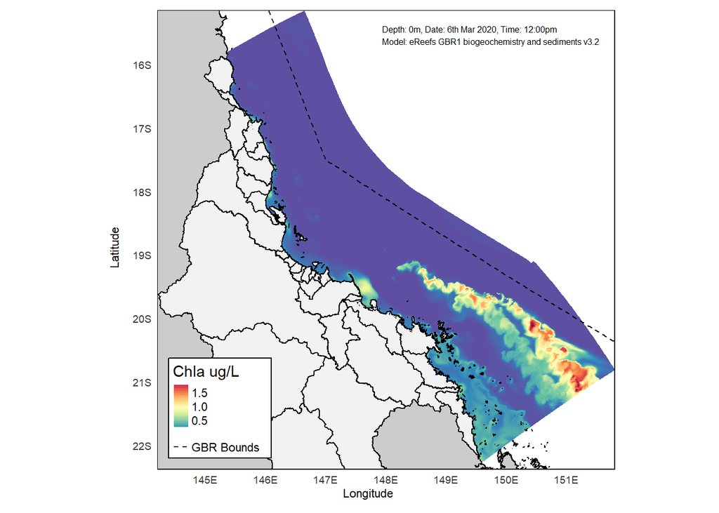

```r
chla_map
```

# 5 Animations

Then we will download additional data in a smaller area for animations, both map and plot.

```r
#define our zoomed in area of interest
area_of_interest <- c(150.5988, 151.3701, -21.0373, -20.5373)

#input_file <- substitute_filename("catalog")
input_file <- "https://dapds00.nci.org.au/thredds/dodsC/fx3/GBR1_H2p0_B3p2_Cfur_Dnrt.ncml"

#because the data is set out in a curved grid we need to then roughly double our area
lon_buff <- abs(area_of_interest[1] - area_of_interest[2])
lat_buff <- abs(area_of_interest[1] - area_of_interest[2])

#add the buffer
aoi_buffer <- c(area_of_interest[1] - lon_buff, area_of_interest[2] + lon_buff,
                area_of_interest[3] - lat_buff, area_of_interest[4] + lat_buff)

#convert the area of interest into an sfc object
area_of_interest <- st_as_sfc(st_bbox(c(xmin = area_of_interest[1], xmax = area_of_interest[2],
                                        ymin = area_of_interest[3], ymax = area_of_interest[4]),
                                      crs = proj_crs))

#get all grids for the entire dataset
grids <- get_ereefs_grids(input_file)

#get x and y grid specifically
x_grid <- grids[["x_grid"]]
y_grid <- grids[["y_grid"]]

#create an array of FALSE values the same dimensions as the x (and y) grids
outOfBox <- array(FALSE, dim = dim(x_grid))

#change array value to TRUE if the associated value in the x or y grid at the same position is outside our bounding box
if (!is.na(aoi_buffer[1])) {outOfBox <- apply(x_grid, 2, function(x) {(x < aoi_buffer[1] | is.na(x))})}
if (!is.na(aoi_buffer[2])) {outOfBox <- outOfBox | apply(x_grid, 2, function(x) {(x > aoi_buffer[2] | is.na(x))})}
if (!is.na(aoi_buffer[3])) {outOfBox <- outOfBox | apply(y_grid, 2, function(x) {(x < aoi_buffer[3] | is.na(x))})}
if (!is.na(aoi_buffer[4])) {outOfBox <- outOfBox | apply(y_grid, 2, function(x) {(x > aoi_buffer[4] | is.na(x))})}

#find the first x position (row) that is inside the bounding box (i.e. the first row with at least one TRUE val)
xmin <- which(apply(!outOfBox, 1, any))[1]

#find all (rows) inside the bounding box (i.e. all rows with at least one TRUE val) then take the last using length() as the index
xmax <- which(apply(!outOfBox, 1, any))
xmax <- xmax[length(xmax)]

#find the first y position (col) that is inside the bounding box (i.e. the first col with at least one TRUE val)
ymin <- which(apply(!outOfBox, 2, any))[1]

#find all (cols) inside the bounding box (i.e. all cols with at least one TRUE val) then take the last using length() as the index
ymax <- which(apply(!outOfBox, 2, any))
ymax <- ymax[length(ymax)]

#extract buffered version
chla_buffered <- read_ncdf(input_file, var = "Chl_a_sum",
                           ncsub = cbind(start = c(xmin, ymin, 44, 100),
                                         count = c((xmax - xmin), (ymax - ymin), 1, 30)))

#overwrite the "fake" NA values
chla_buffered[(chla_buffered > 100)] <- NA

#update crs
chla_buffered <- st_transform(chla_buffered, proj_crs)

#crop to the actually area we are interested in
nc_chla_zoomed <- st_crop(chla_buffered, area_of_interest)

#update the name of the layer for the legend in the map
names(nc_chla_zoomed) <- "Chla ug/L"

#clean up
rm(input_file, lon_buff, lat_buff, aoi_buffer, grids, x_grid, y_grid, outOfBox,
   xmin, xmax, ymin, ymax, chla_buffered)
```

## 5.1 Map Animation

Now we will create said animations, with an additional static map to show where the animation is occurring:

(Note the map animation cant be shown in the doc).

```r
#create list to store maps
map_list <- list()

#loop through each layer and add to list
for (i in 1:30){

  #plot
  tm_object <- tm_shape(nc_chla_zoomed[,,,,i]) +
    tm_raster(style = "cont", legend.reverse = T, palette = "-Spectral", breaks = c(0, 0.5, 1, 1.5, 2)) +
    tm_layout(legend.outside = T) +
    tm_shape(area_of_interest, is.master = T) +
    tm_polygons(alpha = 0, border.alpha = 0)

  #append each to a list
  map_list <- c(map_list, list(tm_object))

}

#supply to the list of tmap objects to the animate function
tmap_animation(map_list, filename =  glue("{save_outputs}/chla_map_animation.gif"), width = 500, height = 500, fps = 2)

#create the map with the area of interest overlaid
prety_chla <- tm_shape(qld) +
  tm_polygons(col = "grey80", border.col = "Black") +
  tm_grid(alpha = 0, labels.show = T, labels.cardinal = T, col = "Black") +
  tm_xlab("Longitude", size = 0.7) +
  tm_ylab("Latitude", size = 0.7) +
  tm_shape(nc_chla, is.master = T) +
  tm_raster(style = "cont", palette = "-Spectral", legend.reverse = T) +
  tm_shape(n3_land_region) +
  tm_polygons(col = "grey95", border.col = "Black") +
  tm_shape(gbrmpa_bound) +
  tm_borders(lty = "dashed", col = "black") +
  tm_shape(area_of_interest) +
  tm_borders(col = "red", lwd = 2) +
  tm_layout(legend.frame = T, legend.position = c("left", "bottom"), legend.bg.color = "White") +
  tm_add_legend(type = "line", lty = "dashed", col = "black", labels = "GBR Bounds")  +
  tm_credits(text = "Depth: 0m, Date: 6th Mar 2020, Time: 12:00pm \nModel: eReefs GBR1 biogeochemistry and sediments v3.2",
             position = c("right", "top"),
             size = 0.5, col = "Black")

#save
tmap_save(prety_chla, filename = glue("{save_outputs}/chla_pretty_aoi_overlay.png"))
```

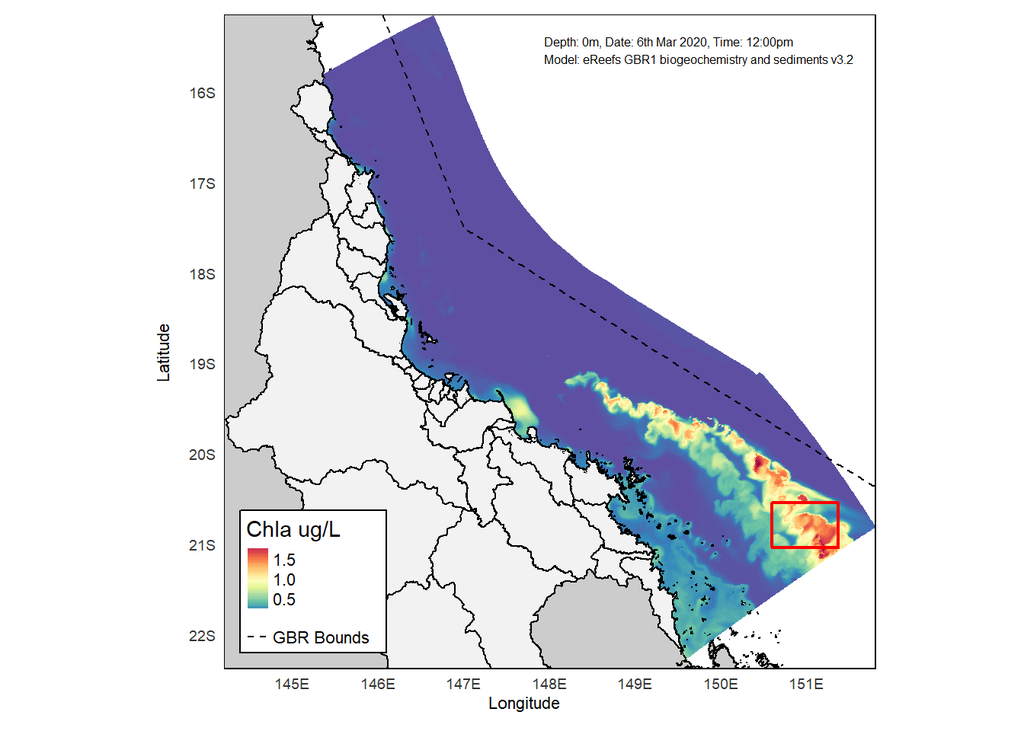

```r
prety_chla
```

## 5.2 Plot Animation

Then we will follow this up with an animation of a plot.

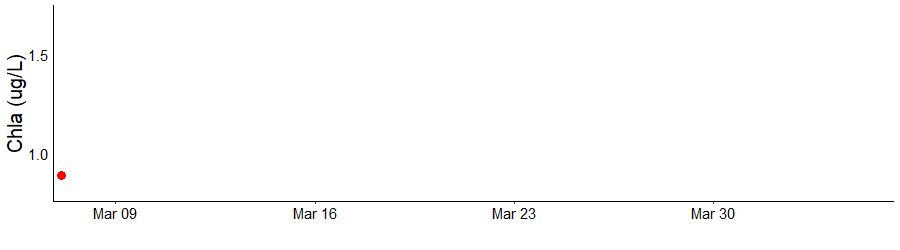

```r
#extract data from the zoomed in area for each day
chla_data_extract <- data.frame(st_extract(nc_chla_zoomed, area_of_interest, fun = mean))

#create a line plot of the data
plot <- ggplot(chla_data_extract, aes(x = time, y = Chla.ug.L)) +
  geom_line(col = "Black", linewidth = 1.5) +
  geom_point(col = "Red", size = 4) +
  scale_y_continuous(breaks = c(0.5, 1, 1.5, 2), limits = c(0.8, 1.7), name = "Chla (ug/L)") +
  scale_x_datetime(name = "", expand = c(0.01, 0.01)) +
   theme(axis.text.x = element_text(colour = "black", size = 15),
         axis.line.x = element_line(colour = "black"),
         axis.text.y = element_text(colour = "black", size = 15),
         axis.line.y = element_line(colour = "black"),
         axis.title = element_text(colour = "black", size = 20),
         axis.ticks.y = element_blank(),
         panel.background = element_blank()) +
  transition_reveal(time)

#animate the plot
animate(plot, duration = 15, height = 250, width = 900)
```

```r
#save the plot (the last (most recent) animation that was made)
anim_save(glue("{save_outputs}/chla_plot_animation.gif"), last_animation())

#we will also save the data to be inspected if needed
chla_data_clean <- chla_data_extract |> select(Chla.ug.L, time) |>
  separate_wider_delim(time, " ", names = c("date", NA)) |>
  rename(chla = Chla.ug.L) |>
  pivot_wider(names_from = date, values_from = chla)

#save
write_csv(chla_data_clean, glue("{save_outputs}/chla_example_data.csv"))
```

# 6 Session Info

Below is the session info at the time of rendering this script. Of greatest importance is to note the R version, and the “other attached packages” as these are the most significant drivers of success/failure. It is also good to check the “attached base packages” and “loaded via a namespace” packages as well. To check your session info use `sessionInfo()`.

[session information not shown]